# Lab 05

caojilin

2/22/2018

```r
library(dplyr)
```

```r
library(ggplot2)
dat = read.csv('../data/nba2017-players.csv', stringsAsFactors = FALSE)
# use slice() to subset the data by selecting the first 5 rows.
five_rows = slice(dat,1:5)
five_rows
```

```
## # A tibble: 5 x 15
##   player   team  position height weight   age experience college    salary
##   <chr>    <chr> <chr>     <int>  <int> <int>      <int> <chr>       <dbl>
## 1 Al Horf… BOS   C            82    245    30          9 Universit… 2.65e⁷
## 2 Amir Jo… BOS   PF           81    240    29         11 ""         1.20e⁷
## 3 Avery B… BOS   SG           74    180    26          6 Universit… 8.27e⁶
## 4 Demetri… BOS   PG           73    201    22          0 Universit… 1.45e⁶
## 5 Gerald … BOS   SF           79    205    31          9 ""         1.41e⁶
## # ... with 6 more variables: games <int>, minutes <int>, points <int>,
## #   points3 <int>, points2 <int>, points1 <int>
```

```r
# use slice() to subset the data by selecting rows 10, 15, 20, ..., 50.
slice(dat,seq(10,50,5))
```

```
## # A tibble: 9 x 15
##   player   team  position height weight   age experience college    salary
##   <chr>    <chr> <chr>     <int>  <int> <int>      <int> <chr>       <dbl>
## 1 Jonas J… BOS   PF           82    231    29          6 ""         5.00e⁶
## 2 Tyler Z… BOS   C            84    253    27          4 Universit… 8.00e⁶
## 3 Edy Tav… CLE   C            87    260    24          1 ""         5.14e³
## 4 Kevin L… CLE   PF           82    251    28          8 Universit… 2.12e⁷
## 5 Tristan… CLE   C            81    238    25          5 Universit… 1.53e⁷
## 6 DeMarre… TOR   SF           80    215    30          7 Universit… 1.42e⁷
## 7 Lucas N… TOR   C            84    241    24          2 ""         1.92e⁶
## 8 Serge I… TOR   PF           82    235    27          7 ""         1.22e⁷
## 9 Daniel … WAS   C            83    245    23          0 Villanova… 5.43e⁵
## # ... with 6 more variables: games <int>, minutes <int>, points <int>,
## #   points3 <int>, points2 <int>, points1 <int>
```

```r
# use slice() to subset the data by selecting the last 5 rows.
slice(dat,(length(dat$player)-4):length(dat$player))
```

```
## # A tibble: 5 x 15
##   player   team  position height weight   age experience college    salary
##   <chr>    <chr> <chr>     <int>  <int> <int>      <int> <chr>       <dbl>
## 1 Marques… PHO   PF           82    233    19          0 Universit… 2.94e⁶
## 2 Ronnie … PHO   PG           74    190    33         11 Utah Vall… 2.83e⁵
## 3 T.J. Wa… PHO   SF           80    230    23          2 North Car… 2.13e⁶
## 4 Tyler U… PHO   PG           70    150    21          0 Universit… 9.18e⁵
## 5 Tyson C… PHO   C            85    240    34         15 ""         1.24e⁷
## # ... with 6 more variables: games <int>, minutes <int>, points <int>,
## #   points3 <int>, points2 <int>, points1 <int>
```

```r
slice(dat,437:441)
```

```
## # A tibble: 5 x 15
##   player   team  position height weight   age experience college    salary
##   <chr>    <chr> <chr>     <int>  <int> <int>      <int> <chr>       <dbl>
## 1 Marques… PHO   PF           82    233    19          0 Universit… 2.94e⁶
## 2 Ronnie … PHO   PG           74    190    33         11 Utah Vall… 2.83e⁵
## 3 T.J. Wa… PHO   SF           80    230    23          2 North Car… 2.13e⁶
## 4 Tyler U… PHO   PG           70    150    21          0 Universit… 9.18e⁵
## 5 Tyson C… PHO   C            85    240    34         15 ""         1.24e⁷
## # ... with 6 more variables: games <int>, minutes <int>, points <int>,
## #   points3 <int>, points2 <int>, points1 <int>
```

```r
slice(dat,(nrow(dat)-4):nrow(dat))
```

```
## # A tibble: 5 x 15
##   player   team  position height weight   age experience college    salary
##   <chr>    <chr> <chr>     <int>  <int> <int>      <int> <chr>       <dbl>
## 1 Marques… PHO   PF           82    233    19          0 Universit… 2.94e⁶
## 2 Ronnie … PHO   PG           74    190    33         11 Utah Vall… 2.83e⁵
## 3 T.J. Wa… PHO   SF           80    230    23          2 North Car… 2.13e⁶
## 4 Tyler U… PHO   PG           70    150    21          0 Universit… 9.18e⁵
## 5 Tyson C… PHO   C            85    240    34         15 ""         1.24e⁷
## # ... with 6 more variables: games <int>, minutes <int>, points <int>,
## #   points3 <int>, points2 <int>, points1 <int>
```

```r
# use filter() to subset those players with height less than 70 inches tall.
filter(dat,height<70)
```

```
##          player team position height weight age experience
## 1 Isaiah Thomas  BOS       PG     69    185  27          5
## 2    Kay Felder  CLE       PG     69    176  21          0
##                    college  salary games minutes points points3 points2
## 1 University of Washington 6587132    76    2569   2199     245     437
## 2       Oakland University  543471    42     386    166       7      55
##   points1
## 1     590
## 2      35
```

```r
# use filter() to subset rows of Golden State Warriors ('GSW').
filter(dat,team=='GSW')
```

```
##                  player team position height weight age experience
## 1        Andre Iguodala  GSW       SF     78    215  33         12
## 2          Damian Jones  GSW        C     84    245  21          0
## 3            David West  GSW        C     81    250  36         13
## 4        Draymond Green  GSW       PF     79    230  26          4
## 5             Ian Clark  GSW       SG     75    175  25          3
## 6  James Michael McAdoo  GSW       PF     81    230  24          2
## 7          JaVale McGee  GSW        C     84    270  29          8
## 8          Kevin Durant  GSW       SF     81    240  28          9
## 9          Kevon Looney  GSW        C     81    220  20          1
## 10        Klay Thompson  GSW       SG     79    215  26          5
## 11          Matt Barnes  GSW       SF     79    226  36         13
## 12        Patrick McCaw  GSW       SG     79    185  21          0
## 13     Shaun Livingston  GSW       PG     79    192  31         11
## 14        Stephen Curry  GSW       PG     75    190  28          7
```

[output cut: 33 more lines]

```r
# use filter() to subset rows of GSW centers ('C').
filter(dat,team=='GSW' & position =='C')
```

```
##          player team position height weight age experience
## 1  Damian Jones  GSW        C     84    245  21          0
## 2    David West  GSW        C     81    250  36         13
## 3  JaVale McGee  GSW        C     84    270  29          8
## 4  Kevon Looney  GSW        C     81    220  20          1
## 5 Zaza Pachulia  GSW        C     83    270  32         13
##                                 college  salary games minutes points
## 1                 Vanderbilt University 1171560    10      85     19
## 2                     Xavier University 1551659    68     854    316
## 3            University of Nevada, Reno 1403611    77     739    472
## 4 University of California, Los Angeles 1182840    53     447    135
## 5                                       2898000    70    1268    426
##   points3 points2 points1
## 1       0       8       3
## 2       3     132      43
## 3       0     208      56
## 4       2      54      21
## 5       0     164      98
```

```r
# use filter() and then select(), to subset rows of lakers ('LAL'), and then display their names.
select(filter(dat,team=='LAL'),player)
```

```
##               player
## 1     Brandon Ingram
## 2       Corey Brewer
## 3   D'Angelo Russell
## 4        David Nwaba
## 5        Ivica Zubac
## 6    Jordan Clarkson
## 7      Julius Randle
## 8    Larry Nance Jr.
## 9          Luol Deng
## 10 Metta World Peace
## 11        Nick Young
## 12       Tarik Black
## 13   Thomas Robinson
## 14    Timofey Mozgov
## 15       Tyler Ennis
```

```r
# use filter() and then select(), to display the name and salary, of GSW point guards
select(filter(dat,team=='GSW' & position=='PG'),player,salary)
```

```
##             player   salary
## 1 Shaun Livingston  5782450
## 2    Stephen Curry 12112359
```

```r
# find how to select the name, age, and team, of players with more than 10 years of experience, making 10 million dollars or less.
select(filter(dat,experience >10 & salary <10000000),player,age,team)
```

```
##               player age team
## 1      Dahntay Jones  36  CLE
## 2     Deron Williams  32  CLE
## 3        James Jones  36  CLE
## 4        Kyle Korver  35  CLE
## 5  Richard Jefferson  36  CLE
## 6      Jose Calderon  35  ATL
## 7     Kris Humphries  31  ATL
## 8      Mike Dunleavy  36  ATL
## 9        Jason Terry  39  MIL
## 10        C.J. Miles  29  IND
## 11     Udonis Haslem  36  MIA
## 12        Beno Udrih  34  DET
## 13        David West  36  GSW
## 14       Matt Barnes  36  GSW
```

[output cut: 18 more lines]

```r
# find how to select the name, team, height, and weight, of rookie players, 20 years old, displaying only the first five occurrences (i.e. rows)
select(slice(filter(dat,age==20 & experience == 0),1:5),player,age,team,height,weight)
```

```
## # A tibble: 5 x 5
##   player              age team  height weight
##   <chr>             <int> <chr>  <int>  <int>
## 1 Jaylen Brown         20 BOS       79    225
## 2 Henry Ellenson       20 DET       83    245
## 3 Stephen Zimmerman    20 ORL       84    240
## 4 Dejounte Murray      20 SAS       77    170
## 5 Chinanu Onuaku       20 HOU       82    245
```

```r
gsw <- filter(dat, team == 'GSW')
gsw <- select(gsw, player, height, weight)
gsw <- slice(gsw, c(4, 8, 10, 14, 15))
gsw
```

```
## # A tibble: 5 x 3
##   player         height weight
##   <chr>           <int>  <int>
## 1 Draymond Green     79    230
## 2 Kevin Durant       81    240
## 3 Klay Thompson      79    215
## 4 Stephen Curry      75    190
## 5 Zaza Pachulia      83    270
```

```r
# using the data frame gsw, add a new variable product with the product of height and weight.
mutate(gsw,product=height*weight)
```

```
## # A tibble: 5 x 4
##   player         height weight product
##   <chr>           <int>  <int>   <int>
## 1 Draymond Green     79    230   18170
## 2 Kevin Durant       81    240   19440
## 3 Klay Thompson      79    215   16985
## 4 Stephen Curry      75    190   14250
## 5 Zaza Pachulia      83    270   22410
```

```r
# create a new data frame gsw3, by adding columns log_height and log_weight with the log transformations of height and weight.
gsw3 = mutate(gsw,log_height_and_weight=log(height,base=10)+log(weight,base=10))
# use the original data frame to filter() and arrange() those players with height less than 71 inches tall, in increasing order.
arrange(filter(dat,height <71),height)
```

```
##          player team position height weight age experience
## 1 Isaiah Thomas  BOS       PG     69    185  27          5
## 2    Kay Felder  CLE       PG     69    176  21          0
## 3    Tyler Ulis  PHO       PG     70    150  21          0
##                    college  salary games minutes points points3 points2
## 1 University of Washington 6587132    76    2569   2199     245     437
## 2       Oakland University  543471    42     386    166       7      55
## 3   University of Kentucky  918369    61    1123    444      21     163
##   points1
## 1     590
## 2      35
## 3      55
```

```r
# display the name, team, and salary, of the top-5 highest paid players
slice(select(arrange(dat,desc(salary)),player,team,salary),1:5)
```

```
## # A tibble: 5 x 3
##   player        team    salary
##   <chr>         <chr>    <dbl>
## 1 LeBron James  CLE   30963450
## 2 Al Horford    BOS   26540100
## 3 DeMar DeRozan TOR   26540100
## 4 Kevin Durant  GSW   26540100
## 5 James Harden  HOU   26540100
```

```r
# display the name, team, and salary, for the top-5 highest paid players
slice(select(arrange(dat,desc(salary)),player,team,salary),1:5)
```

```
## # A tibble: 5 x 3
##   player        team    salary
##   <chr>         <chr>    <dbl>
## 1 LeBron James  CLE   30963450
## 2 Al Horford    BOS   26540100
## 3 DeMar DeRozan TOR   26540100
## 4 Kevin Durant  GSW   26540100
## 5 James Harden  HOU   26540100
```

```r
# display the name, team, and points3, of the top 10 three-point players
slice(select(arrange(dat,desc(points3)),player,team,points3),1:10)
```

```
## # A tibble: 10 x 3
##    player         team  points3
##    <chr>          <chr>   <int>
##  1 Stephen Curry  GSW       324
##  2 Klay Thompson  GSW       268
##  3 James Harden   HOU       262
##  4 Eric Gordon    HOU       246
##  5 Isaiah Thomas  BOS       245
##  6 Kemba Walker   CHO       240
##  7 Bradley Beal   WAS       223
##  8 Damian Lillard POR       214
##  9 Ryan Anderson  HOU       204
## 10 J.J. Redick    LAC       201
```

```r
# create a data frame gsw_mpg of GSW players, that contains variables for player name, experience, and min_per_game (minutes per game), sorted by min_per_game (in descending order)
gsw_mpg = filter(dat,team=='GSW')
gsw_mpg = mutate(gsw_mpg,min_per_game=minutes/games)
gsw_mpg = select(arrange(gsw_mpg,desc(min_per_game)),player,experience,min_per_game)
gsw_mpg
```

```
##                  player experience min_per_game
## 1         Klay Thompson          5    33.961538
## 2         Stephen Curry          7    33.392405
## 3          Kevin Durant          9    33.387097
## 4        Draymond Green          4    32.513158
## 5        Andre Iguodala         12    26.289474
## 6           Matt Barnes         13    20.500000
## 7         Zaza Pachulia         13    18.114286
## 8      Shaun Livingston         11    17.697368
## 9         Patrick McCaw          0    15.126761
## 10            Ian Clark          3    14.766234
## 11           David West         13    12.558824
## 12         JaVale McGee          8     9.597403
## 13 James Michael McAdoo          2     8.788462
## 14         Damian Jones          0     8.500000
## 15         Kevon Looney          1     8.433962
```

```r
# use summarise() to get the largest height value.
summarise(dat,max(height))
```

```
##   max(height)
## 1          87
```

```r
# use summarise() to get the standard deviation of points3.
summarise(dat,sd(points3))
```

```
##   sd(points3)
## 1     55.9721
```

```r
# use summarise() and group_by() to display the median of three-points, by team.
summarise(group_by(dat,team),median_points3=median(points3))
```

```
## # A tibble: 30 x 2
##    team  median_points3
##    <chr>          <dbl>
##  1 ATL             32.5
##  2 BOS             46.0
##  3 BRK             44.0
##  4 CHI             32.0
##  5 CHO             17.0
##  6 CLE             62.0
##  7 DAL             53.0
##  8 DEN             53.0
##  9 DET             28.0
## 10 GSW             18.0
## # ... with 20 more rows
```

```r
# display the average triple points by team, in ascending order, of the bottom-5 teams (worst 3pointer teams)
slice(arrange(summarise(group_by(dat,team),ave3=mean(points3)),ave3),1:5)
```

```
## # A tibble: 5 x 2
##   team   ave3
##   <chr> <dbl>
## 1 NOP    36.6
## 2 SAC    37.2
## 3 PHO    37.6
## 4 CHI    37.7
## 5 LAL    39.5
```

```r
# obtain the mean and standard deviation of age, for Power Forwards, with 5 and 10 years (including) years of experience.
summarise(filter(dat,position=='PF',experience >=5 & experience <=10),mean_age=mean(age),sd_age=sd(age))
```

```
##   mean_age   sd_age
## 1 28.12903 1.802627
```

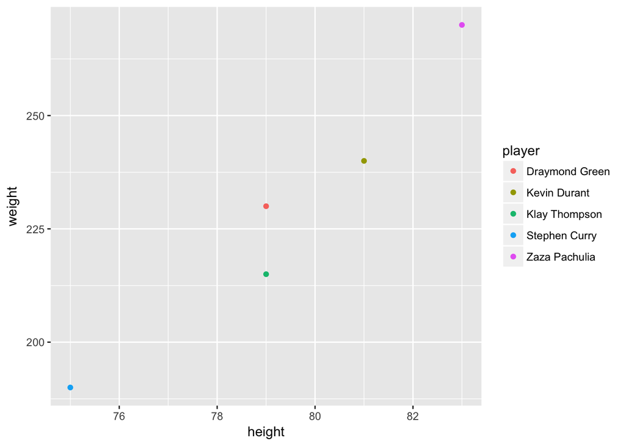

```r
# Open the ggplot2 cheatsheet
# Use the data frame gsw to make a scatterplot of height and weight.
ggplot(data= gsw,aes(x=height,y=weight)) + geom_point(aes(color=player))
```

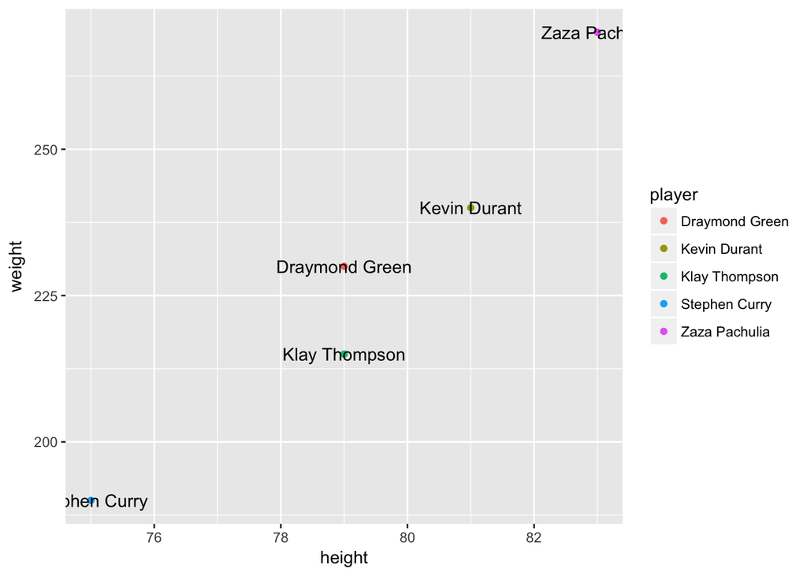

```r
# Find out how to make another scatterplot of height and weight, using geom_text() to display the names of the players.
ggplot(data= gsw,aes(x=height,y=weight)) + geom_point(aes(color=player))+geom_text(aes(label=player))
```

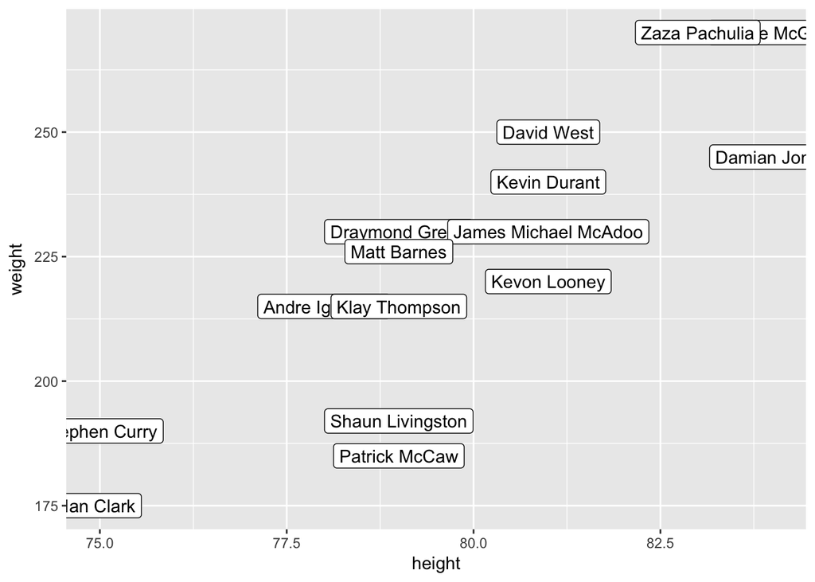

```r
# Get a scatter plot of height and weight, for ALL the warriors, displaying their names with geom_label().
gsw1 = filter(dat,team=='GSW')
ggplot(data=select(gsw1,player,height,weight),aes(x=height,y=weight))+geom_label(aes(label=player),check_overlap=TRUE)
```

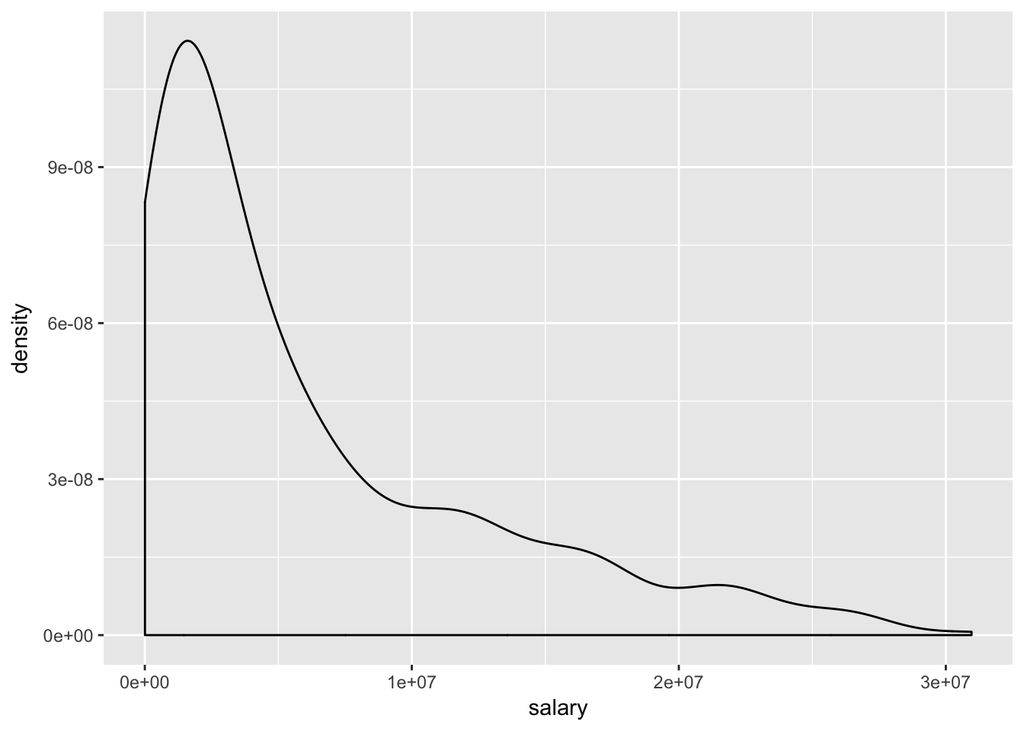

```r
# Get a density plot of salary (for all NBA players).
ggplot(data= select(dat,salary),aes(salary)) + geom_density()
```

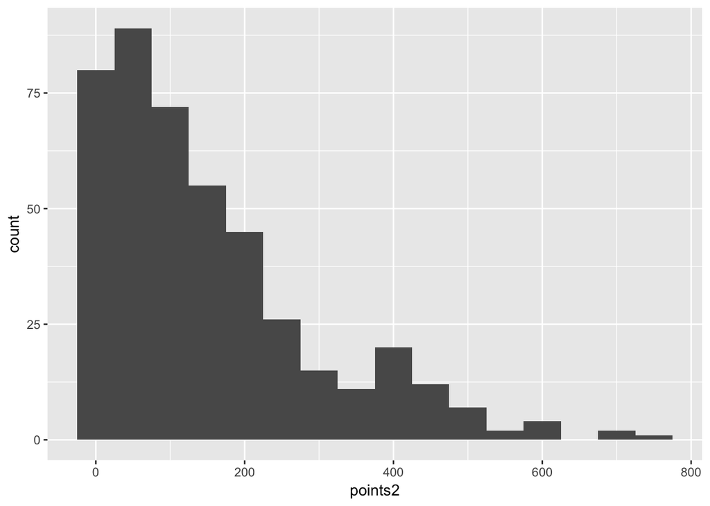

```r
# Get a histogram of points2 with binwidth of 50 (for all NBA players).
ggplot(data= select(dat,points2),aes(points2)) + geom_histogram(binwidth=50)
```

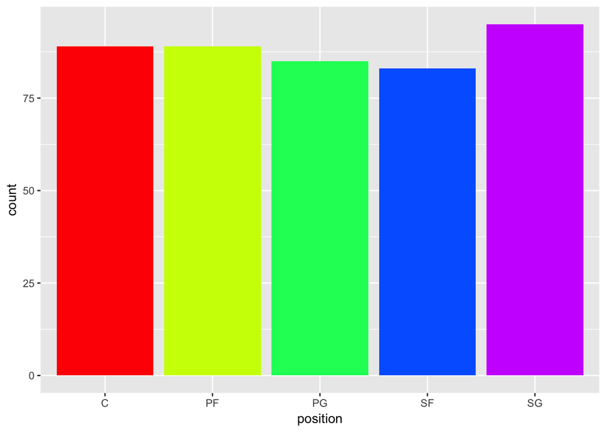

```r
# Get a barchart of the position frequencies (for all NBA players).
ggplot(data= select(dat,position),aes(position))+geom_bar(fill=rainbow(n=5))
```

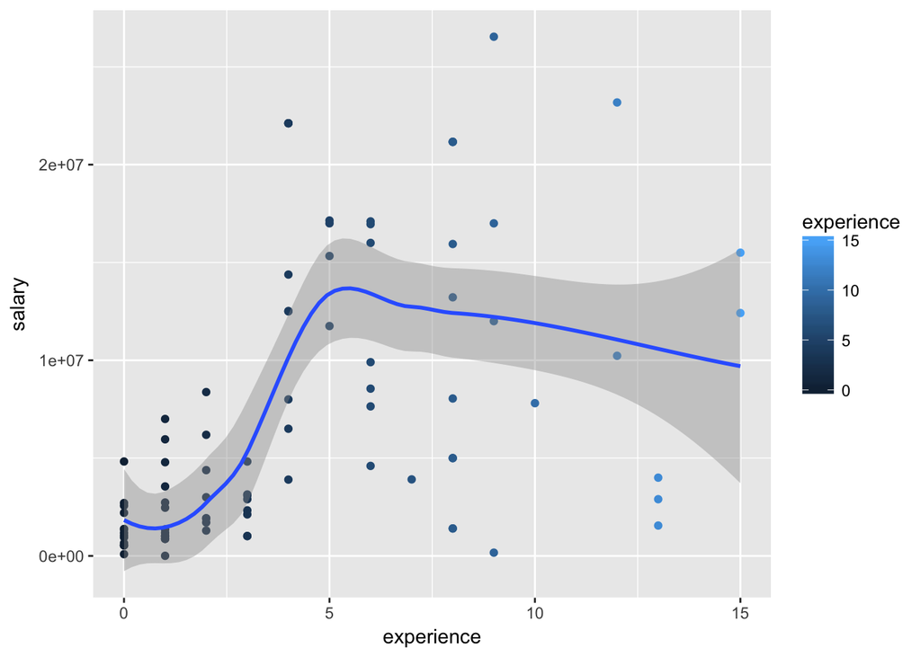

```r
# Make a scatterplot of experience and salary of all Centers, and use geom_smooth() to add a regression line.
ggplot(data = filter(dat,position=='C'),aes(x=experience,y=salary)) +geom_point(aes(color=experience)) + geom_smooth()
```

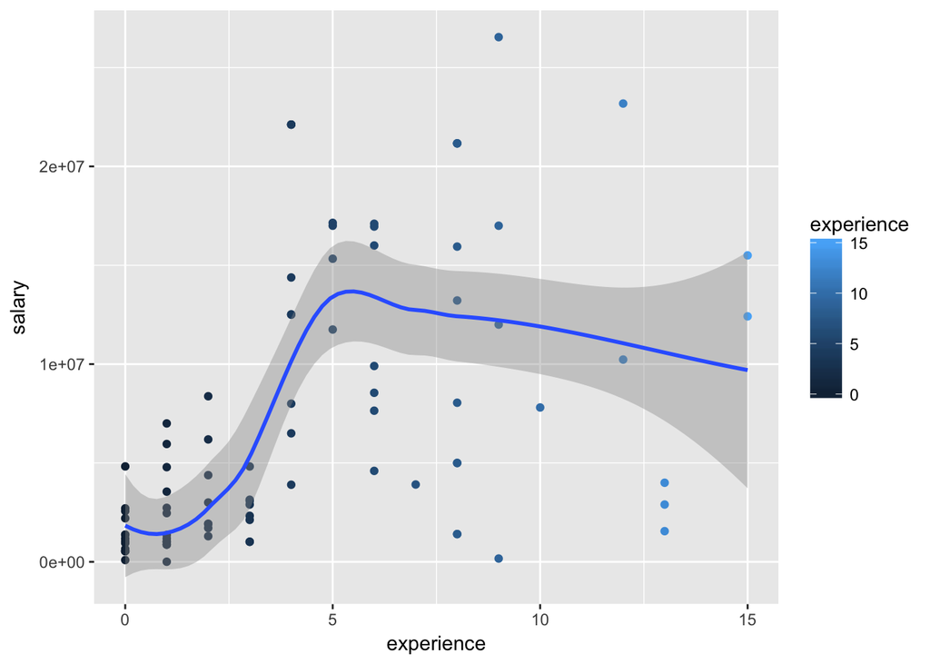

```r
# Repeat the same scatterplot of experience and salary of all Centers, but now use geom_smooth() to add a loess line (i.e. smooth line).
ggplot(data = filter(dat,position=='C'),aes(x=experience,y=salary)) +geom_point(aes(color=experience)) + geom_smooth(method='loess')
```

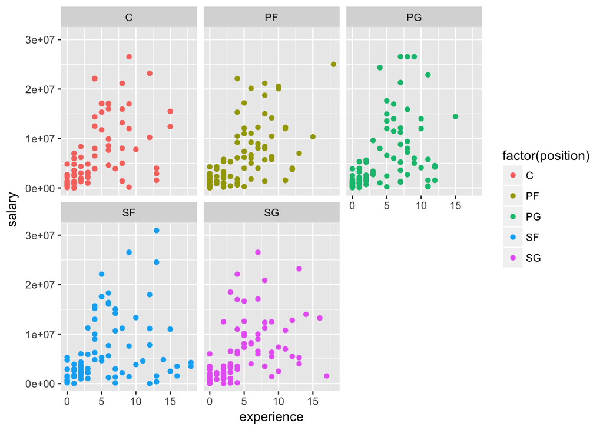

```r
# Make scatterplots of experience and salary faceting by position
ggplot(data=dat,aes(x=experience,y=salary))+geom_point(aes(color=factor(position)))+facet_wrap(~ position)
```

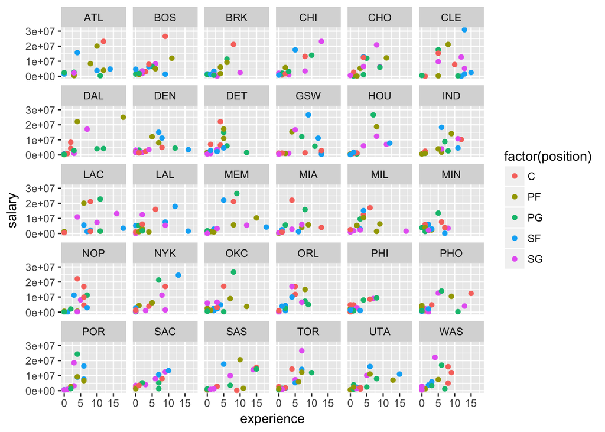

```r
# Make scatterplots of experience and salary faceting by team
ggplot(data=dat,aes(x=experience,y=salary))+geom_point(aes(color=factor(position)))+facet_wrap(~ team)
```

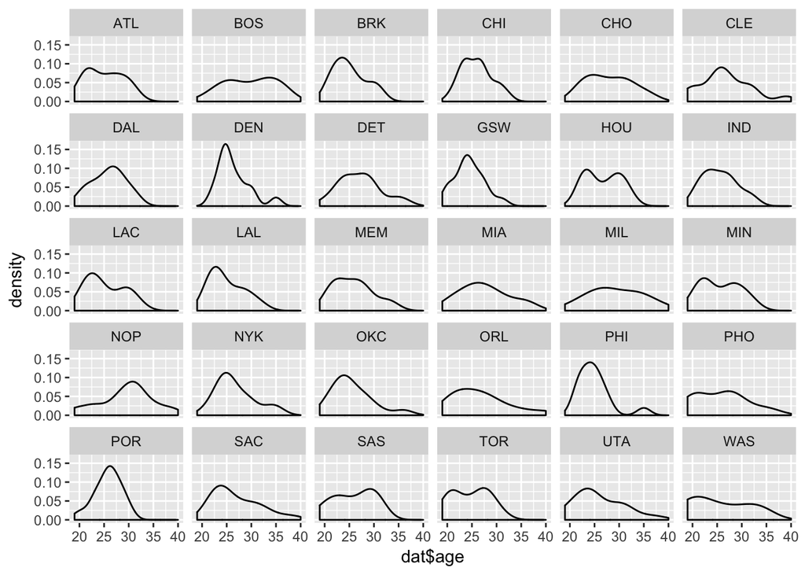

```r
# Make density plots of age faceting by team
ggplot(data=dat)+geom_density(aes(dat$age))+facet_wrap(~ team)
```

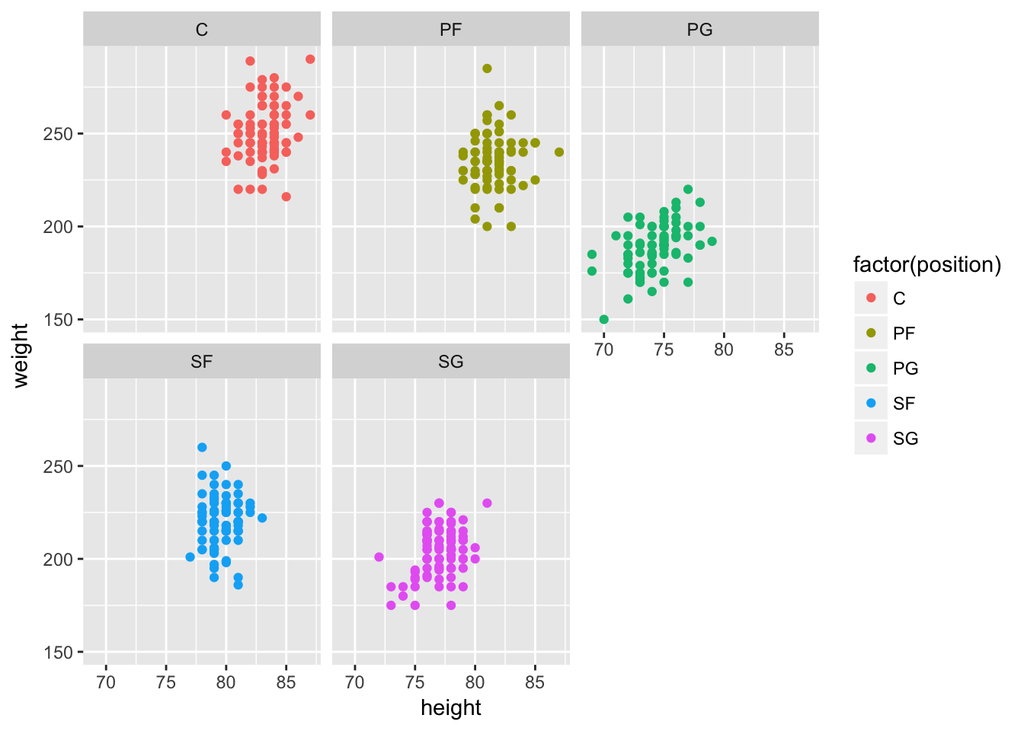

```r
# Make scatterplots of height and weight faceting by position
ggplot(data=dat,aes(x=height,y=weight))+geom_point(aes(color=factor(position)))+facet_wrap(~ position)
```

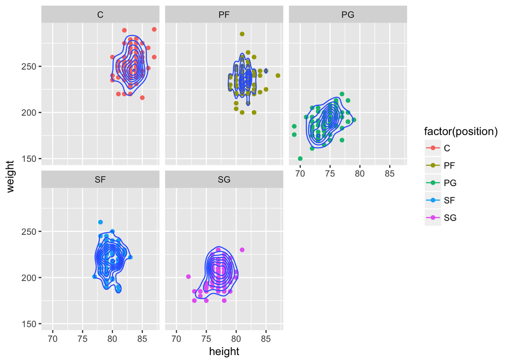

```r
# Make scatterplots of height and weight, with a 2-dimensional density, geom_density2d(), faceting by position
ggplot(data=dat,aes(x=height,y=weight))+geom_point(aes(color=factor(position)))+facet_wrap(~ position)+geom_density2d()
```

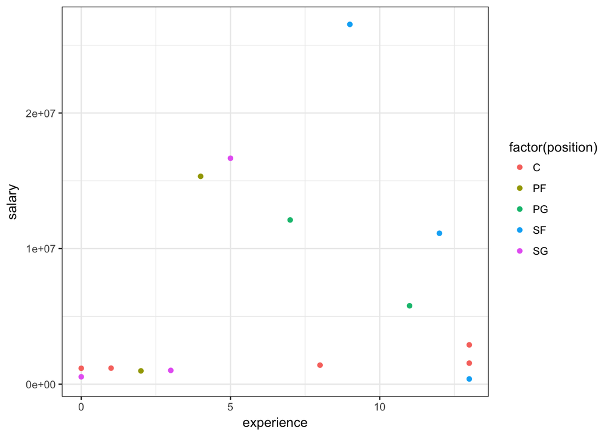

```r
# Make a scatterplot of experience and salary for the Warriors, but this time add a layer with theme_bw() to get a simpler background
ggplot(data=dat[dat$team=='GSW',],aes(x=experience,y=salary))+geom_point(aes(color=factor(position)))+theme_bw()
```

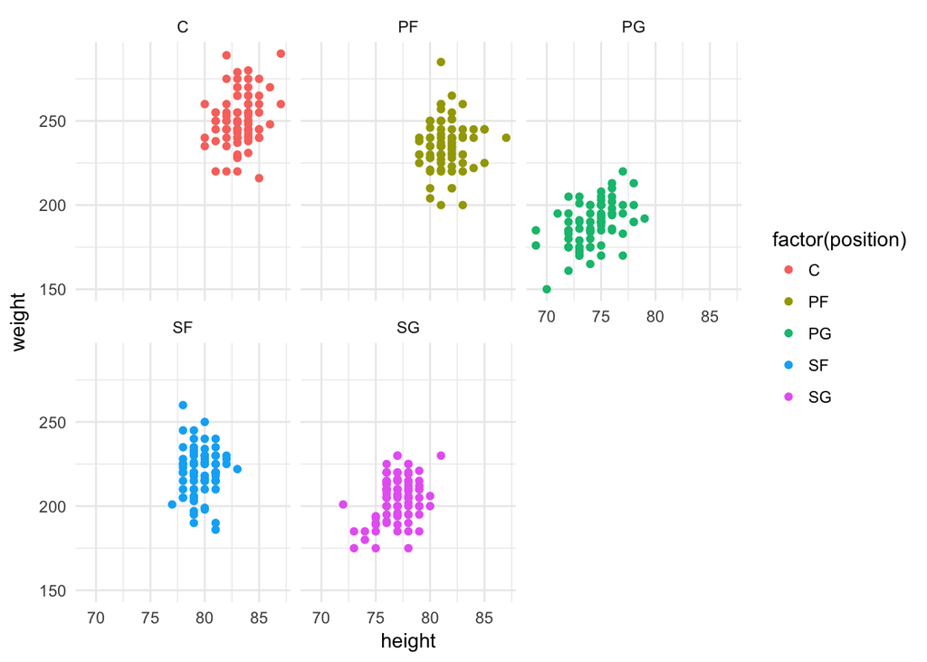

```r
# Repeat any of the previous plots but now adding a leyer with another theme e.g. theme_minimal(), theme_dark(), theme_classic()
ggplot(data=dat,aes(x=height,y=weight))+geom_point(aes(color=factor(position)))+facet_wrap(~ position)+theme_minimal()
```

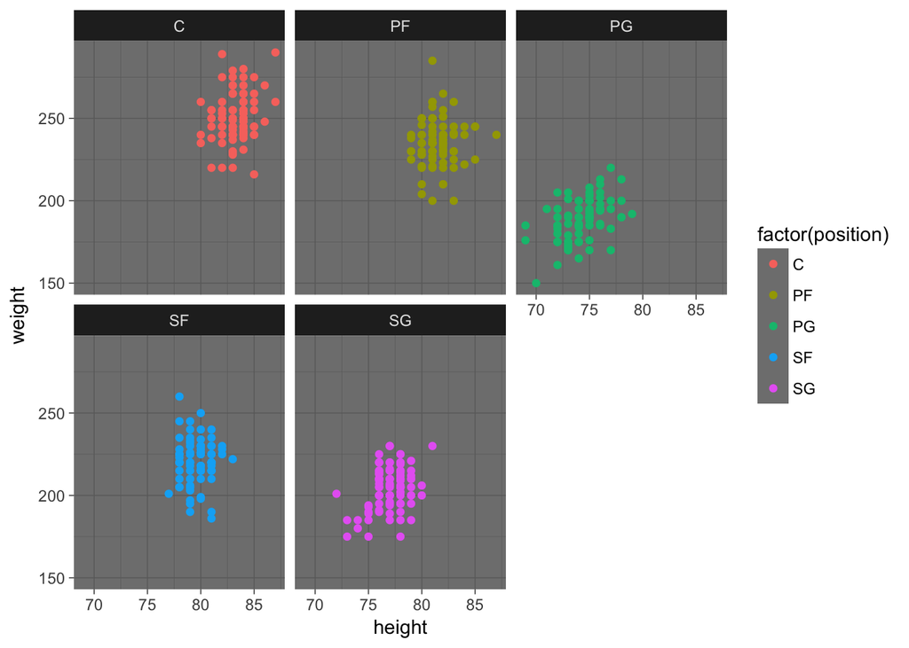

```r
ggplot(data=dat,aes(x=height,y=weight))+geom_point(aes(color=factor(position)))+facet_wrap(~ position)+theme_dark()
```

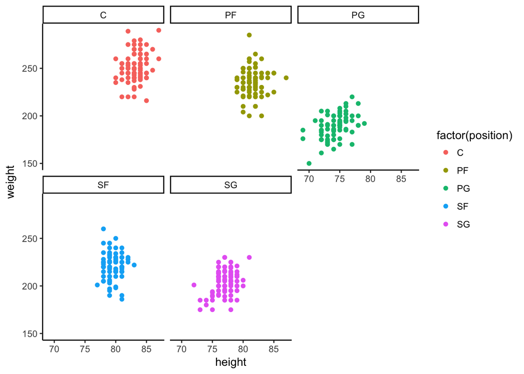

```r
ggplot(data=dat,aes(x=height,y=weight))+geom_point(aes(color=factor(position)))+facet_wrap(~ position)+theme_classic()
```

Open the terminal. Move inside the images/ directory of the lab. List the contents of this directory  
ls  
Now list the contents of the directory in long format.  
ls -l  
How would you list the contents in long format, by time?  
ls -lt  
How would you list the contents displaying the results in reverse (alphabetical)? order  
ls -r  
Without changing your current directory, create a directory copies at the parent level (i.e. lab05/).  
mkdir ../copies  
Copy one of the PNG files to the copies folder.

cp unnamed-chunk-5-9.png ../copies

Use the wildcard * to copy all the .png files in the directory copies.  
cp **.png ../copies/

Change to the directory copies.  
cd ../copies/  
Use the command mv to rename some of your PNG files.  
mv unnamed-chunk-4-1.png 4-1.png

Change to the report/ directory.  
cd ../report/  
From within report/, find out how to rename the directory copies as copy-files.  
mv ../copies/ copy-files  
From within report/, delete one or two PNG files in copy-files.  
rm copy-files/4-1.png  
From within report/, find out how to delete the directory copy-files.  
rm -r copy-files